Kuan-I Lu, brian901231@gmail.com

2024-08-13

# Introduction

Within the definition of Taiwanese legislation, a company called a “startup” is one that operates with an innovative technology or business model. Throughout Taiwanese history, there have been more than 5,000 companies that fall under the definition of a “startup,” the most famous case being TSMC, which to this day is still the global leader in semiconductor chip manufacturing. Investors of all scales then raised the question: Which startup company can be the next TSMC, or even reach half of its achievements? Therefore, predicting the success of companies has become a crucial issue to address. In this project, this is the exact task we aim to tackle: we will build machine learning models to try to predict the success of companies based on the various variables provided in the dataset.

## Introducing the Data

We have a list of .csv files, each containing a dataset from a class of industries (hardware, internet services, AI, etc.). The data includes the name of the company, founding date, the industries the companies are considered in, the number of employees, the estimated annual revenue, and more. We need to come up with an outcome variable denoting the success of the company. With domain knowledge and consideration from the investor and entrepreneur’s perspectives, we decided that if a start-up has reached Initial Public Offering (IPO) or Mergers and Acquisitions (M&A), then the company would be considered successful. Additionally, if a start-up obtained early-stage funding (seed, early-stage venture), and the funding amount exceeds a certain percentile compared to other companies that also recieved early stage funding, we would also consider the company to be successful. If the company obtained early-stage funding but not with an exceptional amount, we would say the company has good potential rather than directly labeling it a failure. For all the other companies that did not gain funding of any kind, we would consider these companies not successful. One thing worth mentioning is that there are some companies (for example, 1111 Job Bank) that started off with strong stakeholders and didn’t find themselves in need of funding of any kind. These companies are rather rare. These successful companies are being classified as failures with our method, so we will take this into account and see if necessary actions are required to accommodate this phenomenon in the EDA stage of this project.

# Cleaning the Data

## Load the Data

Here, we load the necessary packages and the datasets. The structure we have is a short list of observations for every industry. We will first merge the various datasets into one big dataset and then perform further cleaning.

```r
library(tidyverse)
library(tidymodels)
library(dplyr)
library(lubridate)
library(finalfit)
library(ggplot2)
library(corrplot)
library(themis)
library(kknn)
library(ranger)
library(vip)
library(VIM)
library(janitor)
library(gridExtra)
```

```r
#Load the data and combine them into one data set

startup_data_1 = read_csv("data/administrative services=/companies-2023-10-12.csv")
startup_data_2 = read_csv("data/advertising=/companies-2023-10-12.csv")
startup_data_3 = read_csv("data/agriculture and farming=/companies-2023-10-12.csv")
startup_data_4 = read_csv("data/AI=/companies-2023-10-12.csv")
startup_data_5 = read_csv("data/apps=/companies-2023-10-12.csv")
startup_data_6 = read_csv("data/biotechnology=/companies-2023-10-12.csv")
startup_data_7 = read_csv("data/clothing and shopping=/companies-2023-10-12.csv")
startup_data_8 = read_csv("data/commerce and shopping=/companies-2023-10-12.csv")
startup_data_9 = read_csv("data/community and lifestyle=/companies-2023-10-12.csv")
startup_data_10 = read_csv("data/consumer electronics=/companies-2023-10-12.csv")
startup_data_11 = read_csv("data/consumer goods=/companies-2023-10-12.csv")
startup_data_12 = read_csv("data/content and publishing=/companies-2023-10-12.csv")
startup_data_13 = read_csv("data/data and analytics=/companies-2023-10-12.csv")
startup_data_14 = read_csv("data/design=/companies-2023-10-12.csv")
startup_data_15 = read_csv("data/education=/companies-2023-10-12.csv")
startup_data_16 = read_csv("data/energy=/companies-2023-10-12.csv")
startup_data_17 = read_csv("data/event=/companies-2023-10-12.csv")
startup_data_18 = read_csv("data/financial services=/companies-2023-10-12.csv")
startup_data_19 = read_csv("data/food and beverage=/companies-2023-10-12.csv")
startup_data_20 = read_csv("data/gaming=/companies-2023-10-12.csv")
startup_data_21 = read_csv("data/government and military=/companies-2023-10-12.csv")
startup_data_22_1 = read_csv("data/hardware=/companies-2023-10-12-1.csv")
startup_data_22_2 = read_csv("data/hardware=/companies-2023-10-12-2.csv")
startup_data_22 = rbind(startup_data_22_1, startup_data_22_2)
startup_data_23 = read_csv("data/information technology=/companies-2023-10-12.csv")
startup_data_24 = read_csv("data/internet services=/companies-2023-10-12.csv")
startup_data_25 = read_csv("data/lending and investment=/companies-2023-10-12.csv")
startup_data_26_1 = read_csv("data/manufacturing=/companies-2023-10-12-1.csv")
startup_data_26_2 = read_csv("data/manufacturing=/companies-2023-10-12-2.csv")
startup_data_26_3 = read_csv("data/manufacturing=/companies-2023-10-12-3.csv")
startup_data_26 = rbind(startup_data_26_1, startup_data_26_2, startup_data_26_3)
startup_data_27 = read_csv("data/media and entertainment=/companies-2023-10-12.csv")
startup_data_28 = read_csv("data/messaging and telecommunications=/companies-2023-10-12.csv")
startup_data_29 = read_csv("data/mobile=/companies-2023-10-12.csv")
startup_data_30 = read_csv("data/music and audio=/companies-2023-10-12.csv")
startup_data_31 = read_csv("data/natural and resources=/companies-2023-10-12.csv")
startup_data_32 = read_csv("data/navigation and mapping=/companies-2023-10-12.csv")
startup_data_33 = read_csv("data/other=/companies-2023-10-12.csv")
startup_data_34 = read_csv("data/payments=/companies-2023-10-12.csv")
startup_data_35 = read_csv("data/platforms=/companies-2023-10-12.csv")
startup_data_36 = read_csv("data/privacy and security=/companies-2023-10-12.csv")
startup_data_37 = read_csv("data/professional services/companies-2023-10-12.csv")
startup_data_38 = read_csv("data/real estate/companies-2023-10-12.csv")
startup_data_39 = read_csv("data/sales and marketing/companies-2023-10-12.csv")
startup_data_40_1 = read_csv("data/science and engineering/companies-2023-10-12-1.csv")
startup_data_40_2 = read_csv("data/science and engineering/companies-2023-10-12-2.csv")
startup_data_40 = rbind(startup_data_40_1, startup_data_40_2)
startup_data_41 = read_csv("data/software/companies-2023-10-12.csv")
startup_data_42 = read_csv("data/sport/companies-2023-10-12.csv")
startup_data_43 = read_csv("data/sustainability/companies-2023-10-12.csv")
startup_data_44 = read_csv("data/transportation/companies-2023-10-12.csv")
startup_data_45 = read_csv("data/travel and tourism/companies-2023-10-12.csv")
startup_data_46 = read_csv("data/video/companies-2023-10-12.csv")

industry_names = c(
  "Administrative Services",
  "Advertising",
  "Agriculture and Farming",
  "AI",
  "Apps",
  "Biotechnology",
  "Clothing and Shopping",
  "Commerce and Shopping",
  "Community and Lifestyle",
  "Consumer Electronics",
  "Consumer Goods",
  "Content and Publishing",
  "Data and Analytics",
  "Design",
  "Education",
  "Energy",
  "Event",
  "Financial Services",
  "Food and Beverage",
  "Gaming",
  "Government and Military",
  "Hardware",
  "Information Technology",
  "Internet Services",
  "Lending and Investment",
  "Manufacturing",
  "Media and Entertainment",
  "Messaging and Telecommunications",
  "Mobile",
  "Music and Audio",
  "Natural and Resources",
  "Navigation and Mapping",
  "Other",
  "Payments",
  "Platforms",
  "Privacy and Security",
  "Professional Services",
  "Real Estate",
  "Sales and Marketing",
  "Science and Engineering",
  "Software",
  "Sport",
  "Sustainability",
  "Transportation",
  "Travel and Tourism",
  "Video"
)

startup_list = list()
for (i in seq_along(industry_names)) {
  dataset_name = paste0("startup_data_", i)
  startup_list[[industry_names[i]]] = get(dataset_name)
}

startup_data = rbind(startup_data_1, startup_data_2, startup_data_3, startup_data_4, startup_data_5, startup_data_6, startup_data_7, startup_data_8, startup_data_9, startup_data_10, startup_data_11, startup_data_12, startup_data_13, startup_data_14, startup_data_15, startup_data_16, startup_data_17, startup_data_18, startup_data_19, startup_data_20, startup_data_21, startup_data_22_1, startup_data_22_2, startup_data_23, startup_data_24, startup_data_25, startup_data_26_1, startup_data_26_2, startup_data_26_3, startup_data_27, startup_data_28, startup_data_29, startup_data_30, startup_data_31, startup_data_32, startup_data_33, startup_data_34, startup_data_35, startup_data_36, startup_data_37, startup_data_38, startup_data_39, startup_data_40_1, startup_data_40_2, startup_data_41, startup_data_42, startup_data_43, startup_data_44, startup_data_45, startup_data_46)

startup_data = startup_data %>%
  distinct()

paste("Number of companies: ", nrow(startup_data))
```

```
## [1] "Number of companies:  4786"
```

Here, we can see that we have 4786 observations.

## Excluding New Companies

Some of the newly established companies may not have realized their potential, so we don’t want to draw conclusions about them yet. Therefore, we want to build our models only on the older companies and use the model to predict the performance of the newer companies. To do this, we will transform the `Founded Date` variable to `founded_year` and then exclude the newer companies.

```r
#transform the date and only extract the year out of `Founded Date`
startup_data = startup_data %>%
  mutate(founded_year = year(`Founded Date`))

#check the amount of companies founded after 2019
startup_data_2019_up = startup_data %>%
  filter(founded_year >= 2019)

paste("Number of comapnies founded in 2019 or later: ", nrow(startup_data_2019_up))
```

```
## [1] "Number of comapnies founded in 2019 or later:  307"
```

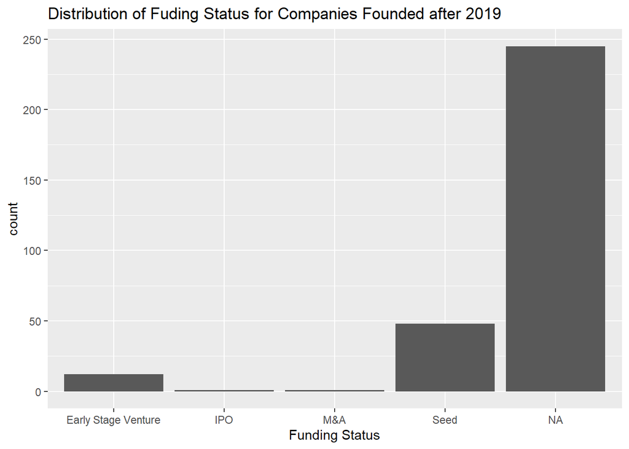

```r
startup_data_2019_up %>%
  ggplot(aes(x = `Funding Status`)) + geom_bar() +
  labs(title = "Distribution of Fuding Status for Companies Founded after 2019")
```

Observe that there are 307 startups founded after the year 2019, among which only two have reached IPO or M&A, and the others that received funding are all seed/early stage ventures. Furthermore, most companies in this category still haven’t received any form of funding yet. From this observation, we can conclude that these newer companies are still at an earlier stage of their development, and it would make sense to exclude them for the purpose of our model.

Instead of using these newer companies to train our model, we would use the fitted model to predict the future performance of these companies, treating them as our target. So, we will only be working with companies that were founded before the year 2019.

```r
#filter out the companies founded after 2019
startup_data = startup_data %>%
  filter(founded_year < 2019)

paste("Number of remaining companies: ", nrow(startup_data))
```

```
## [1] "Number of remaining companies:  3965"
```

## Filter Out Useless Variables

Since this is a very comprehensive dataset containing all kinds of information (including more than 100 columns), we want to filter out the useless predictors (contact, webpage link, etc.)

```r
startup_data = startup_data %>%
  select(`Organization Name`, `Headquarters Location`, `Estimated Revenue Range`, `Operating Status`, `Company Type`, `Number of Articles`, `Full Description`, `Number of Sub-Orgs`, `Number of Investments`, `Industry Groups`, `Industries`, `Number of Founders`, `Number of Employees`, `Number of Funding Rounds`, `Funding Status`, `Total Funding Amount Currency (in USD)`, `Top 5 Investors`, `Number of Lead Investors`, `Number of Investors`, `CB Rank (Organization)`, `CB Rank (Company)`, `Trend Score (7 Days)`, `Trend Score (30 Days)`, `Trend Score (90 Days)`, `Similar Companies`, `SEMrush - Monthly Visits`, `SEMrush - Average Visits (6 months)`, `SEMrush - Monthly Visits Growth`, `SEMrush - Visit Duration`, `SEMrush - Visit Duration Growth`, `SEMrush - Page Views / Visit`, `SEMrush - Page Views / Visit Growth`, `SEMrush - Bounce Rate`, `SEMrush - Bounce Rate Growth`, `SEMrush - Global Traffic Rank`, `SEMrush - Monthly Rank Growth`, `BuiltWith - Active Tech Count`, `Apptopia - Number of Apps`, `Apptopia - Downloads Last 30 Days`, `G2 Stack - Total Products Active`, `IPqwery - Patents Granted`, `IPqwery - Trademarks Registered`, `IPqwery - Most Popular Patent Class`, `IPqwery - Most Popular Trademark Class`, `founded_year`)
```

We have roughly filtered out the useless predictors and reduced to around 50 columns. Note that the remaining columns are not entirely “useful” since many of them contains mostly NA values. We will take a deeper look at the columns with too many NA values and filter the dataset one more time after we clean and create the variables we need.

## Create Outcome Variable: success

We want to classify the level of success of our companies into three levels. Those that reached IPO, M&A, or with significant amount of early venture/investment would be consider highly successful, with class “strong”. Those that received early venture/investment but with a smaller amount would be considered a “medium” level of success. Lastly, those with no funding available would be considered “weak”.

First, we want to take a deeper look at the distributions of `Funding Status` among our data set

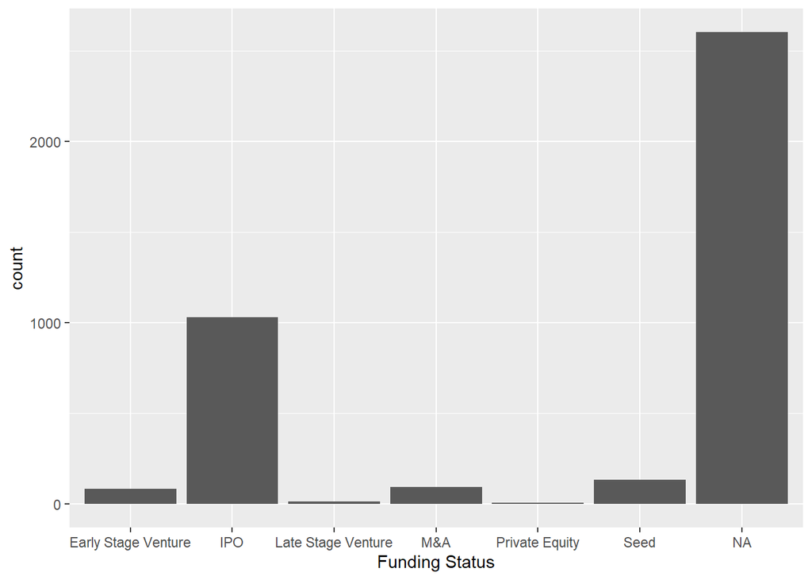

```r
#distribution of `funding status`
startup_data %>%
  ggplot(aes(x = `Funding Status`)) + geom_bar()
```

Notice that a significant amount of companies has NA values, meaning that they didn’t receive funding of any kind, which is imaginable since most start-ups ended up failing. Since we’re splitting those that are not IPO, M&A, or NA (in other words, Early Stage Venture, Late Stage Venture, Private Equity, and Seed) into two categories, we want to take a deeper look into the distribution of these “early funding’ companies.

```r
#look at the funding amount for non IPO or M&A
temp = startup_data %>%
  filter(!(`Funding Status` %in% c("IPO", "M&A", NA)))

paste("Number of companies recieving early funding: ", nrow(temp))
```

```
## [1] "Number of companies recieving early funding:  240"
```

```r
temp = temp %>%
  filter(is.na(`Total Funding Amount Currency (in USD)`))

paste("Number of companies missing exact funding amount: ", nrow(temp))
```

```
## [1] "Number of companies missing exact funding amount:  75"
```

Notice that out of the 240 “early funding’ companies, we’re missing 75 of their exact funding amounts. I think the best thing to do in this scenario is to classify the top percents of those that we have the funding amount of as”strong”, and the rest, no matter having data of funding amount or not, would be considered “medium”.

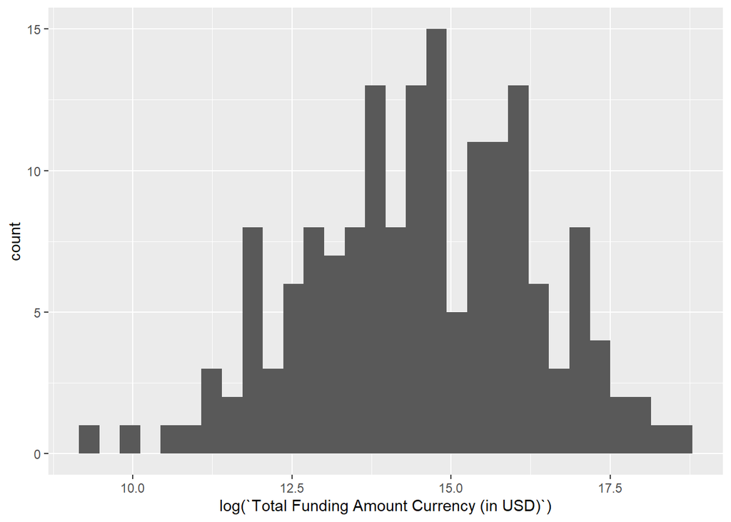

```r
#look at the log of funding amount and see the distribution
startup_data %>%
  filter(!(`Funding Status` %in% c("IPO", "M&A", NA))) %>%
  ggplot(aes(x = log(`Total Funding Amount Currency (in USD)`))) + geom_histogram()
```

With this information in mind, we can start creating the outcome variable `success`.

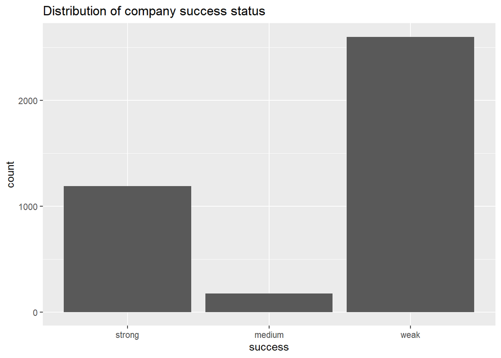

```r
#assign "strong" to all companies reaches IPO or M&A
#assign "weak" to all companies not receiving funding (NA value)
#assign "strong" to companies with log funding amount > 15 among the "early funded" companies
#assign "medium" to companies with log funding amount <= 15 among the "early funded" companies (the remaining companies)

startup_data  = startup_data %>%
  mutate(success = case_when(
    `Funding Status` %in% c("IPO", "M&A") ~ "strong",
    is.na(`Funding Status`) ~ "weak",
    !(`Funding Status` %in% c("IPO", "M&A", NA)) & log(`Total Funding Amount Currency (in USD)`) > 15 ~ "strong",
    TRUE ~ "medium"
  ))

#order success as strong, medium, weak
startup_data$success =factor(startup_data$success, levels = c("strong", "medium", "weak"))

#distribution of the outcome variable, success
startup_data %>%
  ggplot(aes(x = success)) + geom_bar() + labs(title = "Distribution of company success status")
```

## Create industry_group_num and industries_num

Moving on the cleaning of some predictor variables. First, we know that the industry the startup is in highly effects the probability of success. After consulting from experienced industry analyst, we understand that we didn’t really need to worry about the type of industries a company is in, as the more prosperous industry will naturally attract more people to build companies. More importantly, the amount of industries the startup involves in is the better predictor of whether the company will success or not. With this idea in mind, we want to modify a new variable, `industry_group_num`, from the variable `Industry Groups`, and `industries_num` from `Industries`.

```r
startup_data = startup_data %>%
  mutate(industry_group_num = str_count(`Industry Groups`, ",") + 1) %>%
  mutate(industries_num = str_count(`Industries`, ",") + 1)
```

## Create location

Realize that we have 82 different locations, with some companies being the only one from such location, this is a big problem since in the modeling process, we would have extensive dummy variables to effect the quality of training. Therefore, based on the location denoted in the `Headquarters Location` column, we will create a new column `location`` mapping these locations to four classes, “north”, “center”, “south”, and “east” indicating the relative geographic location in Taiwan the company’s headquarter belongs to.

```r
# create a temporary variable Headquarters to store the simplified location name
startup_data = startup_data %>%
  mutate(Headquarters = str_split(`Headquarters Location`, pattern = ", ", simplify = TRUE)) %>%
  mutate(Headquarters = Headquarters[,1])

# Define the categories based on the provided locations
north = c("Taipei", "T'ai-pei", "T'ai-wan", "Taoyüan", "Hsinchu", "Neihu", "Panchiao", "Sanchung",
           "Nankang", "Keelung", "Chungho", "Shulin", "Wuku", "Taipeihsien", "Hsintien", "Tucheng",
           "Hsinchuang", "Shenkeng", "Wanhua", "Linkou", "Taoyüanhsien", "Shihlin", "Chungli",
           "Taishan", "Hsichih", "Yungho", "Tatung", "Taipeh", "Kueishan", "Tapei", "Hukou", "Chupei",
           "Hsienchü", "Hsinchuhsien", "Hsinpei", "Yangmei")

center = c("Taichung", "Miaoli", "Changhua", "Nantou", "Taiping", "Taichunghsien", "Toufen",
            "Fengyüan", "Huatan", "Chunan", "Chunghua", "Miaolihsien", "Changhuahsien", "Chutung",
            "Taichang", "Lukang", "Chang Hwa", "Nantun", "Yüanlin", "Chaoyang", "Chinan", "Penghu")

south = c("Tainan", "Kaohsiung", "Pingtung", "Shanhua", "Annan", "Hsinshih", "Chunglulin",
           "Chihtan (2)", "Hsinhua", "Hsinying", "Kangshan", "Chiai", "Sanmin", "Putzu", "Chungcheng",
           "Minhsiung")

east = c("Toucheng", "Hualien", "Yünlin", "Taitung", "Ilan", "Suao")

# Function to classify locations
classify_location = function(location) {
  if (location %in% north) {
    return("north")
  } else if (location %in% center) {
    return("center")
  } else if (location %in% south) {
    return("south")
  } else if (location %in% east) {
    return("east")
  } else {
    return(NA)  # For locations that do not fit any category
  }
}

# Apply the function to create the new column
startup_data = startup_data %>%
  mutate(location = sapply(Headquarters, classify_location))

# Check the amount of NA values
paste("Percentage of missing values in location: ", sum(is.na(startup_data$location))/length(startup_data$location)*100, "%")
```

```
## [1] "Percentage of missing values in location:  0.126103404791929 %"
```

Note that after cleaning, only 0.1% of data has location of NA values, since it is a trivial amount we will just discard the observations with NA values for location

```r
# remove the observations with NA values for location

startup_data = startup_data %>%
  filter(!is.na(location))
```

## Impute Missing Values

Due to the nature of the data set, we have a lot of missing values. Here, let’s look at the missing values for `Estimated Revenue Range` and `Number of Employees` to see what can we do.

```r
paste("Percentage of missing values in Estimated Revenue Range: ", sum(is.na(startup_data$`Estimated Revenue Range`))/length(startup_data$`Estimated Revenue Range`))
```

```
## [1] "Percentage of missing values in Estimated Revenue Range:  0.553030303030303"
```

```r
paste("Percentage of missing values in Number of Employees: ", sum(is.na(startup_data$`Number of Employees`))/length(startup_data$`Number of Employees`))
```

```
## [1] "Percentage of missing values in Number of Employees:  0.226010101010101"
```

Observe that, over 55% of the observations are missing values for `Estimated Revenue Range`, and over 22% percent of the observations are missing values for `Number of Employees`. Since the values we’re missing is quite a lot, we cannot simply fill it with linear regression or knn. Instead, we know that each companies are classifies in many industries, so we will transform the categorical variable into numerical variables, take the average value of each industry form the imported data sets, then take the average of them based on the `Industry` column. For example, if a company is classified in industries “data”, “food”, and “hardware” and is missing a value for revenue, we will take the average of the industry average for these three industries and replace the missing value.

### revenue

we first transfer the categorical variable `Estimated Revenue Range`, into a numerical variable, `revenue`.

```r
#create revenue column for all startup_data
startup_data = startup_data %>%
  mutate(revenue = case_when(
    `Estimated Revenue Range` == "Less than $1M" ~ 1,
    `Estimated Revenue Range` == "$1M to $10M" ~ 2,
    `Estimated Revenue Range` == "$10M to $50M" ~ 3,
    `Estimated Revenue Range` == "$50M to $100M" ~ 4,
    `Estimated Revenue Range` == "$100M to $500M" ~ 5,
    `Estimated Revenue Range` == "$500M to $1B" ~ 6,
    `Estimated Revenue Range` == "$1B to $10B" ~ 7,
    `Estimated Revenue Range` == "$10B+" ~ 8,
    TRUE ~ NA
  ))
```

Previously we made a list that maps the industry name to a data set of all companies within the industry, `startup_list`, we will first create a `revenue` column for all these data sets and use this list to create a list that maps industry name to the average of revenue

```r
#create revenue column for all data set in startup_list

for (industry in names(startup_list)){
  startup_list[[industry]] = startup_list[[industry]] %>%
    mutate(revenue = case_when(
    `Estimated Revenue Range` == "Less than $1M" ~ 1,
    `Estimated Revenue Range` == "$1M to $10M" ~ 2,
    `Estimated Revenue Range` == "$10M to $50M" ~ 3,
    `Estimated Revenue Range` == "$50M to $100M" ~ 4,
    `Estimated Revenue Range` == "$100M to $500M" ~ 5,
    `Estimated Revenue Range` == "$500M to $1B" ~ 6,
    `Estimated Revenue Range` == "$1B to $10B" ~ 7,
    `Estimated Revenue Range` == "$10B+" ~ 8,
    TRUE ~ NA
  ))
}

#create a list revenue_avg that maps industries to average revenue of the industry

revenue_avg = list()
for (industry in names(startup_list)) {
  revenue_avg[[industry]] = mean(startup_list[[industry]]$revenue, na.rm = TRUE)
}
```

Now that we have the list mapping the name of the industry to the industry average revenue, we want to calculate an average based on on the industries involved for those missing a revenue value.

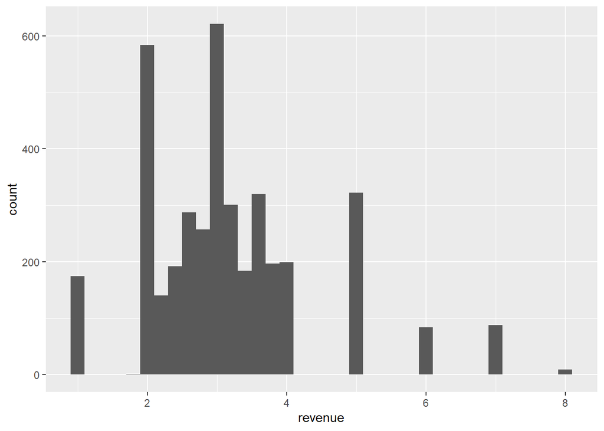

```r
#create a function to calculate the average revenue given the industries
calculate_average_revenue = function(industry_groups, revenue_avg) {
  industries = strsplit(industry_groups, ", ")[[1]]
  mean(unlist(revenue_avg[industries]))
}

#replace the NA values with average_revenue
startup_data = startup_data %>%
  rowwise() %>%
  mutate(
    average_revenue = calculate_average_revenue(`Industry Groups`, revenue_avg),
    revenue = ifelse(is.na(revenue), average_revenue, revenue)
  ) %>%
  select(-average_revenue) # Remove the helper column

# create the plot for employee

revenue_plot = startup_data %>%
  ggplot(aes(x = revenue)) + geom_histogram(binwidth = 0.2)

print(revenue_plot)
```

We have successfully filled in the NA values in column `revenue` using the average of industry average based on the industries the company involves in. Looking at the distribution of `revenue` we can see, since we fill in the values with average, we have a cluster between 2 and 4, though not as ideal as getting the data from direct source, this method is still a good representation that reflects the difference in industries and is definitely a better method than replacing NA with 0 or the global mean.

### employee

Similar to how we did for `revenue` we will quantify the column `Number of Employees` into `employee` and fill the NA values using the average of industry average the company involves in.

```r
#create employee column for all startup_data
startup_data = startup_data %>%
  mutate(employee = case_when(
    `Number of Employees` == "1-10" ~ 1,
    `Number of Employees` == "11-50" ~ 2,
    `Number of Employees` == "51-100" ~ 3,
    `Number of Employees` == "101-250" ~ 4,
    `Number of Employees` == "251-500" ~ 5,
    `Number of Employees` == "501-1000" ~ 6,
    `Number of Employees` == "1001-5000" ~ 7,
    `Number of Employees` == "5001-10000" ~ 8,
    `Number of Employees` == "$10000+" ~ 8,
    TRUE ~ NA
  ))
```

Similarly, we create the `employee` column for all classified datasets in startup_list.

```r
#create employee column for all data set in startup_list

for (industry in names(startup_list)){
  startup_list[[industry]] = startup_list[[industry]] %>%
    mutate(employee = case_when(
      `Number of Employees` == "1-10" ~ 1,
      `Number of Employees` == "11-50" ~ 2,
      `Number of Employees` == "51-100" ~ 3,
      `Number of Employees` == "101-250" ~ 4,
      `Number of Employees` == "251-500" ~ 5,
      `Number of Employees` == "501-1000" ~ 6,
      `Number of Employees` == "1001-5000" ~ 7,
      `Number of Employees` == "5001-10000" ~ 8,
      `Number of Employees` == "$10000+" ~ 8,
      TRUE ~ NA
      ))
}

#create a list employee_avg that maps industries to average revenue of the industry

employee_avg = list()
for (industry in names(startup_list)) {
  employee_avg[[industry]] = mean(startup_list[[industry]]$employee, na.rm = TRUE)
}
```

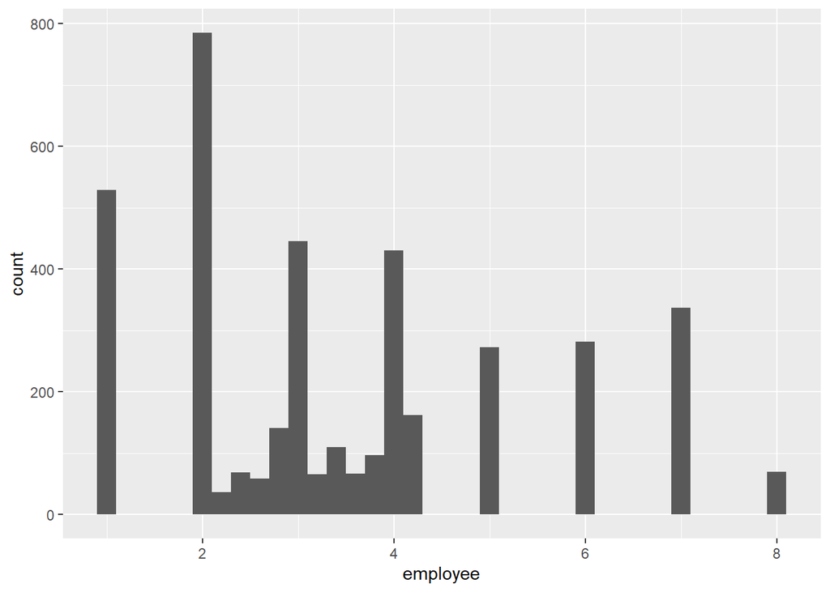

```r
#create a function to calculate the average employee given the industries
calculate_average_employee = function(industry_groups, employee_avg) {
  industries = strsplit(industry_groups, ", ")[[1]]
  mean(unlist(employee_avg[industries]))
}

#replace the NA values with average_employee
startup_data = startup_data %>%
  rowwise() %>%
  mutate(
    average_employee = calculate_average_employee(`Industry Groups`, employee_avg),
    employee = ifelse(is.na(employee), average_employee, employee)
  ) %>%
  select(-average_employee) # Remove the helper column

# create the plot for employee

employee_plot = startup_data %>%
  ggplot(aes(x = employee)) + geom_histogram(binwidth = 0.2)

print(employee_plot)
```

The distribution of imputed `employee` shows similar trend as the distribution of `revenue`. However, since `employee` had less missing values, we have a smaller cluster around the mean values.

### visits

Notice we have multiple columns providing the exposure data from SEMrush, among those the ones that works better as predictors are `SEMrush - Average Visits (6 months)`, but we have a significant amount of missing values in this column. To solve this problem, we will replace the NA values with values in the `SEMrush - Monthly Visits` and we will use knn to fill in the rest of NA values in the next section.

```r
startup_data = startup_data %>%
  mutate(visits = if_else(is.na(`SEMrush - Average Visits (6 months)`),
                          `SEMrush - Monthly Visits`,
                          `SEMrush - Average Visits (6 months)`))
```

## Select Useful Variables

Realize that we still many columns with missing values, we will discard most of them instead of trying to impute all of them since we will end up overfitting with the model we use to impute NA values. Therefore, in this section we will select the variables we need to build our model, while allowing only a few columns containing missing values.

An important note is that, since we’re using this model to make prediction of future companies, we should not include the `founded_year` in our training process as the target data has out-of-range values of `foundede_year` which we would not be training on. Also, as `founded_year` is not one of the most important variable by margin (shown by using the `vip` package), we will not consider our model with the predictor variable `founded_year`.

```r
# Select useful variables
startup_data_new = startup_data %>%
  select(location, `CB Rank (Organization)`, `CB Rank (Company)`, `Trend Score (7 Days)`, `Trend Score (30 Days)`, `Trend Score (90 Days)`, `Similar Companies`, `SEMrush - Page Views / Visit`, `BuiltWith - Active Tech Count`, `industry_group_num`, `industries_num`, `revenue`, `employee`, `visits`, `success`)
```

### Missing values

Lets check one last time for missing values.

[figure not shown]

```r
# create the missing plot for startup_data_new
startup_data_new %>% missing_plot()
```

[figure not shown]

```r
# Remove the observation with too many missing columns and impute the rest NA values with knn model
startup_data_new = startup_data_new %>%
  filter(is.na(`CB Rank (Organization)`) == FALSE) %>%
  kNN(k=5) %>%
  select(location, `CB Rank (Organization)`, `CB Rank (Company)`, `Trend Score (7 Days)`, `Trend Score (30 Days)`, `Trend Score (90 Days)`, `Similar Companies`, `SEMrush - Page Views / Visit`, `BuiltWith - Active Tech Count`, `industry_group_num`, `industries_num`, `revenue`, `employee`, `visits`, `success`)

# create the missing plot for startup_data_new after filling the missing values
startup_missing_new = startup_data_new %>% missing_plot()

print(startup_missing_new)
```

We have successfully cleaned our dataset, note that we might need to come back and change the hyperparameter *k* or consider the companies with missing NA values if the model performance is not ideal.

# Describing the Parameters

Now that we have the cleaned dataset, we will describe our parameters for better understanding of the data:

- `location`: The location where the startup company’s headquarter is located and registered. Taking values from (“north”, “center”, “south”, “east”)
- `CB Rank (Organization)`: Ranking based on Crunchbase’s intelligent algorithms to score and rank general organizations, including company, people, and investors.
- `CB Rank (Company)`: Ranking based on Crunchbase’s intelligent algorithms to score and rank companies.
- `Trend Score (7 Days)`: The score indicating the extent the company is moving up the CB rank over the past 7 days, ranging (-10, 10), with 10 meaning the company moving up the most.
- `Trend Score (30 Days)`: The score indicating the extent the company is moving up the CB rank over the past 30 days, ranging (-10, 10), with 10 meaning the company moving up the most.
- `Trend Score (90 Days)`: The score indicating the extent the company is moving up the CB rank over the past 90 days, ranging (-10, 10), with 10 meaning the company moving up the most.
- `Similar Companies`: The amount of existing similar companies.
- `SEMrush - Page Views / Visit`: The average number of pages a user views during a single visit to a website. This metric gives insights into user engagement and the quality of the site’s content.
- `BuiltWith - Active Tech Count`: The number of distinct technologies currently being utilized on a website.
- `industry_group_num`: The number of industry group the company is involved in.
- `industries_num`: The number of industries the company is involved in. The classification of industries is based on the given dataset.
- `revenue`: The revenue range of the company, denoted in tiers, ranging (1, 8) with 1 being the lowest and 8 being the highest. The revenue tiers are exponentially increasing.
- `employee`: The number of employees of the company, denoted in tiers, ranging (1, 8) with 1 being the lowest and 8 being the highest. The employee tiers are exponentially increasing.
- `visit`: The number of average visits of the company’s website over the last 6 months, for companies missing such value, we use the number of monthly visits to replace the missing value.
- `success`: The classification variable indicating if the company turns out to be successful or not. There are three classes, “strong” meaning the company is successful; “weak” meaning the company is not successful; and “medium” meaning the company is not necessary successful yet but still has great potential.

# EDA

Here we’re going to do some exploratory data analysis, finding some of the interesting trends and relation between our variables.

## Success Distribution

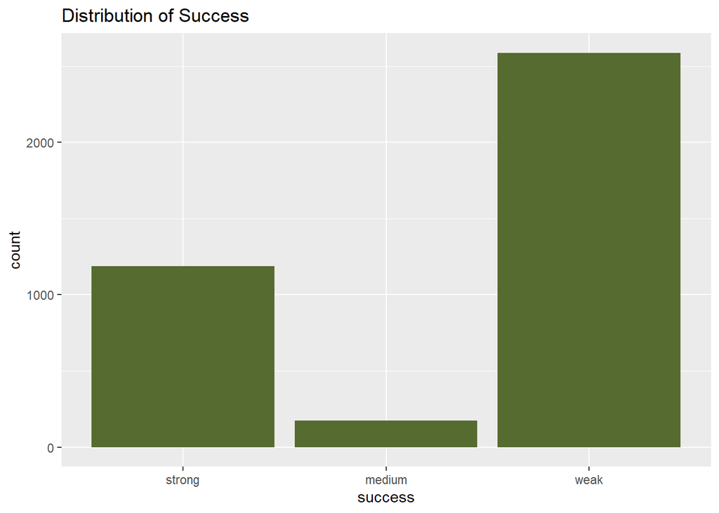

```r
# graph the distribution of success
startup_data_new %>% ggplot(aes(x = success)) + geom_bar(fill = "darkolivegreen") + labs(title = "Distribution of Success")
```

As seen in the graph, most of our companies ended up not being successful, which includes around 65% of the companies. The amount of successful companies, those in the “strong” class, are around 30%. The rest 5% are the companies that are classified as “medium”, those with good potential but had yet to see success.

## Correlation Plot

Here we will be looking at the correlation plot of the numeric variables and see if there’s any interesting patterns.

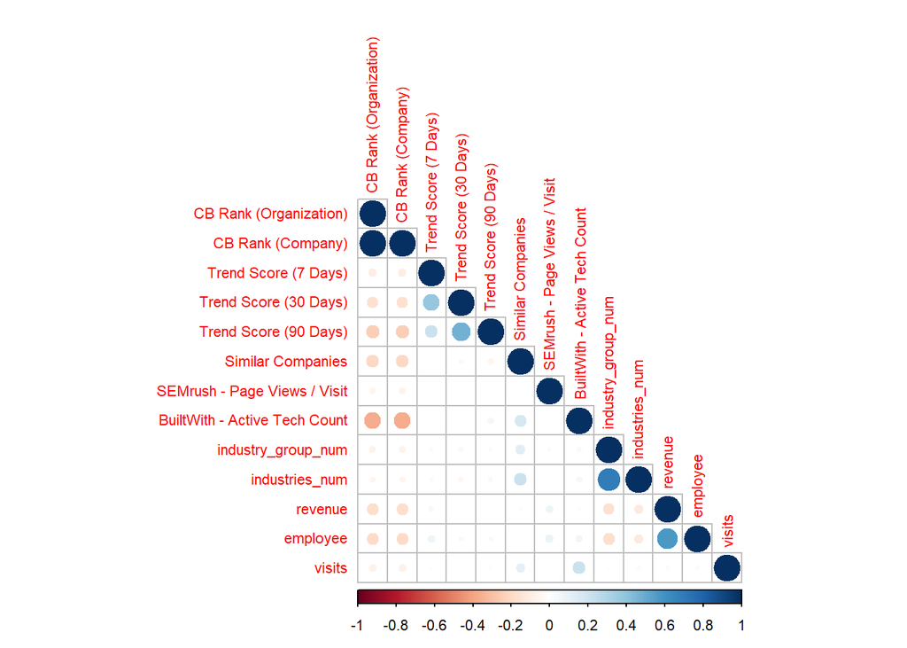

```r
# select only the numeric variables
startup_data_numeric = startup_data_new %>%
  select_if(is.numeric)

#compute the correlation matrix
correlation_matrix = cor(startup_data_numeric)

#plot lower triangle correlation matrix
corrplot(correlation_matrix, type = "lower", tl.cex = 0.7,cl.cex = 0.7)
```

Surprisingly, not many of the variables are significantly correlated. Some of the correlation worth noting are as follows: For the positively correlated variables, `revenue` and `employee` are positively correlated, this makes sense since in order to generate more revenue, we would imagine the company needs more workers; `industry_group_num` and `industry_num` are also positively correlated, this is trivial since these two variables are very similar and almost identical; lastly, `Trend Score` for the past 30 days and the trend score for the past 90 days are also positively correlated, showing that if a company is on the rise for the past month, it’s likely that the company has been on a rise for a longer period, and vise versa.

Moving on to the negatively correlated variables: `CB Rank` and `Active Tech Count` are also negatively correlated, this is an interesting discovery pointing out the fact that the more tech you possess in your website, the rating of your company in CB is going to be higher. However, since both of these metrics are from CB, it would be a reasonable guess to suspect that `CB Rank` is somewhat based on `Active Tech Count`.

Notice that other than the mentioned relation between the predictor variables, the predictors are rather independent, which is an ideal situation since we prefer the correlation among our predictors to be low.

## CB Rank (Company) vs Success

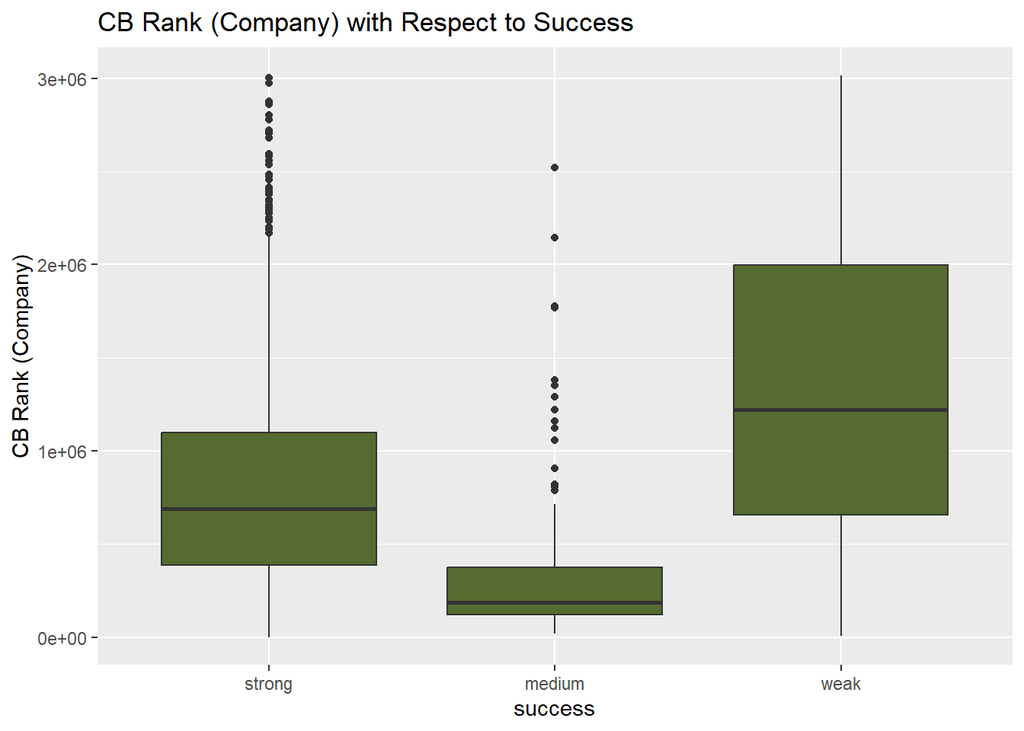

```r
# graph the relation between CB Rank and success
startup_data_new %>% ggplot(aes(x = success, y = `CB Rank (Company)`)) + geom_boxplot(fill = "darkolivegreen") + labs(title = "CB Rank (Company) with Respect to Success", x = "success")
```

## Revenue vs Success

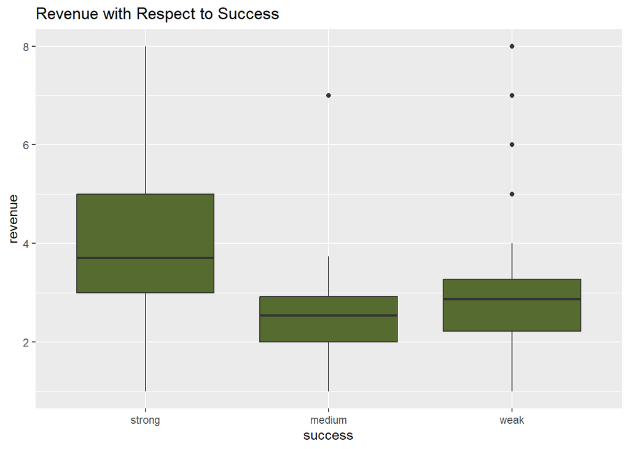

```r
# graph revenue with respect to success
startup_data_new %>% ggplot(aes(x = success, y = revenue)) + geom_boxplot(fill = "darkolivegreen") + labs(title = "Revenue with Respect to Success", x = "success")
```

Now we look at the relation between `revenue` and `success`. The relation seen here is quite imaginable, where if a company generates more revenue, the company is more likely to be successful.

## Employee vs Success

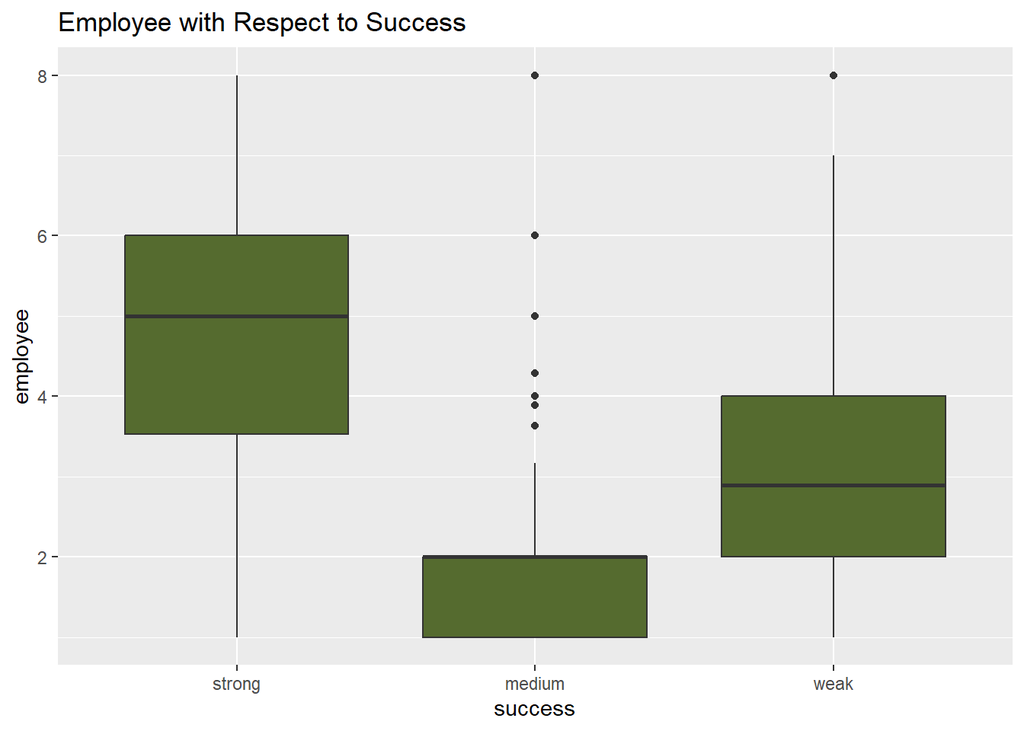

```r
# graph employee with respect to success
startup_data_new %>% ggplot(aes(x = success, y = employee)) + geom_boxplot(fill = "darkolivegreen") + labs(title = "Employee with Respect to Success", x = "success")
```

Similarly for `employee`, if a company has more employees, the chance of it succeeding is expected to be greater. However, notice that the companies with “medium success” have significantly less employee than those that are either “strong” or “weak” this can be because may of the medium companies are at the earlier stage of stratups, therefore having less amount of employees.

## Employee vs Revenue

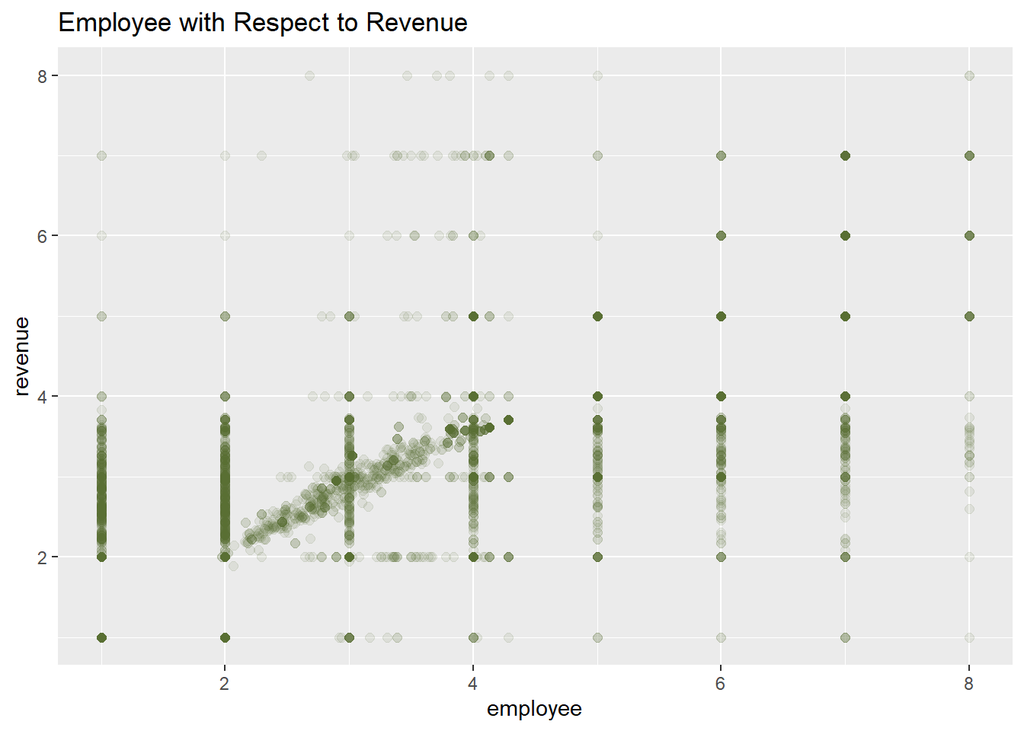

```r
# graph the relation between employee and revenue
startup_data_new %>% ggplot(aes(x = employee, y = revenue)) + geom_point(color = "darkolivegreen", size = 2, alpha = 0.1) + labs(title = "Employee with Respect to Revenue", x = "employee")
```

The visualization of this graph is unorthodox since, for both variables, the data contains discrete values, with the missing values being filled with continuous variables based on the average of such discrete values across industries. From the graph, we can see that employee count and revenue generally follow a positively correlated linear trend, providing evidence that the more employees a company has, the greater the chance that they also generate more revenue.

# Setting Up Models

Now that we have fully cleaned and explored our data we will start building the structure of our model, ,we will perform train test split, along with 10-fold cross validation. We will also try to fit four different models and select the best performing model in terms of predicting if a company is going to be successful or not.

## Train/Test Split

We split the data into a training set and a testing set, with the proportion 75/25. We also stratify our split on the output variable success so that we capture the pattern correctly.

```r
# train/test split the data, stratified on the output variable success
set.seed(20240805)

startup_split = initial_split(startup_data_new, prop = 0.75, strata = "success")

startup_train = training(startup_split)
startup_test = testing(startup_split)
```

## Create Recipe

```r
#create startup recipe
startup_recipe = recipe(success ~ location + `CB Rank (Organization)` + `CB Rank (Company)` + `Trend Score (7 Days)` + `Trend Score (30 Days)` + `Trend Score (90 Days)` + `Similar Companies` + `SEMrush - Page Views / Visit` + `BuiltWith - Active Tech Count` + industry_group_num + industries_num + revenue + employee + visits, data = startup_train) %>%
  step_dummy(all_nominal_predictors()) %>%
  step_downsample(success, under_ratio = 7) %>%
  step_upsample(success, over_ratio = 0.5) %>%
  step_center(all_numeric_predictors()) %>%
  step_scale(all_numeric_predictors())

# prep and bake the recipe to make sure the structure is correct

#startup_recipe %>%
#  prep() %>%
#  bake(startup_train)
```

## K-Fold Cross Validation

To ensure that we are immune from the bias created by error and to prevent overfitting, we wan to use k-fold cross validation with `k=10`. We chose a larger k value because our dataset is rather manageable.

```r
# create 10 fold for k-fold cross validation, stratifying on the output variable success

startup_folds = vfold_cv(startup_train, v = 10, strata = "success")
```

# Fit and Tune Models

Now that we have set up the structure and architecture of our models, we want to select four types of models to train and assess the performance of these models in order to choose the best performing model.

The models that we’re going to try with are, logistic regression, k-nearest neighbor(KNN), elastic net, and random forest. In order to find the best model, we want to tune the different hyperparameters of different models, which are `k` for KNN, `panalty` and `mixture` for elastic net, and `mtry`, `trees`, and `min_n` for random forest.

## Logistic Regression

We implement multinomial logistic regression model to explain our data since we have more than two classes in our outcome variable.

```r
log_model = multinom_reg() %>%
  set_engine("nnet") %>%
  set_mode("classification")

log_wflow = workflow() %>%
  add_model(log_model) %>%
  add_recipe(startup_recipe)
```

## K-Nearest Neightbors

We set up workflow for knn. Note that we are tuning `neighbors` here and we are creating 50 grids to tune from (1, 50). This means we’re fitting $50$ models.

```r
knn_model = nearest_neighbor(neighbors = tune()) %>%
  set_engine("kknn") %>%
  set_mode("classification")

knn_wflow = workflow() %>%
  add_model(knn_model) %>%
  add_recipe(startup_recipe)

knn_grid = grid_regular(neighbors(range = c(1, 50)), levels = 50)
```

## Elastic Net

We set up workflow for elastic net, tuning 10 grids of `penalty` from (-2, 2), and 10 grids of `mixture` from (0, 1). This means we’re fitting $10\times10 = 100$ models.

```r
en_model = multinom_reg(mixture = tune(), penalty = tune()) %>%
  set_engine("glmnet") %>%
  set_mode("classification")

en_wflow = workflow() %>%
  add_model(en_model) %>%
  add_recipe(startup_recipe)

en_grid = grid_regular(penalty(range = c(-2, 2)), mixture(range = c(0, 1)), levels = 10)
```

## Random Forest

We set up workflow for random forest, tuning 10 grids of `mtry` from (1, 10), 10 grids of `trees` from (100, 500), and 7 grids of `min_n` from (2, 8). This means we’re fitting $10\times10\times7 = 700$ models.

```r
rf_model = rand_forest(mtry = tune(), trees = tune(), min_n = tune()) %>%
  set_engine("ranger", importance = "impurity") %>%
  set_mode("classification")

rf_wflow = workflow() %>%
  add_model(rf_model) %>%
  add_recipe(startup_recipe)

mtry_values = seq(1, 10, length.out = 10)
trees_values = seq(100, 500, length.out = 10)
min_n_values = seq(2, 8, length.out = 7)

rf_grid = expand_grid(mtry = mtry_values, trees = trees_values, min_n = min_n_values)
```

## Fit and Tune All Models

Finally, we fit all four models, with the subtotal of $1+50+100+700 = 851$ models each fold into our training set with 10 cross validation folds, totaling with $811\times10=8510$ models. We will assess the performance of these models in the next section.

```r
#fit logistic regression
log_fit = fit_resamples(
  object = log_wflow,
  resamples = startup_folds
)

#tune knn
knn_tune_fit = tune_grid(
  object = knn_wflow,
  resamples = startup_folds,
  grid = knn_grid
)

#tune elastic net
en_tune_fit = tune_grid(
  object = en_wflow,
  resamples = startup_folds,
  grid = en_grid
)

#tune random forest
rf_tune_fit = tune_grid(
  object = rf_wflow,
  resamples = startup_folds,
  grid = rf_grid
)

#save the results in .rda files
save(log_fit, file = "log2.rda")
save(knn_tune_fit, file = "knn2.rda")
save(en_tune_fit, file = "en2.rda")
save(rf_tune_fit, file = "rf2.rda")
```

```r
#load the results
load("log2.rda")
load("knn2.rda")
load("en2.rda")
load("rf2.rda")
```

# Results of All Models

Since we have rather imbalanced output distribution, in addition to using `accuracy` as our metric to assess the goodness of model, we will also use `roc_auc`, area under the ROC curve, to determine if a model is good enough.

## Logistic Regression

```r
# retrieve the accuracy and roc_auc of logistic regression
log_metric = collect_metrics(log_fit)

log_metric %>%
  filter(.metric %in% c("accuracy", "roc_auc")) %>%
  select(.metric, mean, std_err)
```

```
## # A tibble: 2 × 3
##   .metric   mean std_err
##   <chr>    <dbl>   <dbl>
## 1 accuracy 0.727 0.00800
## 2 roc_auc  0.877 0.00789
```

Observe that, from fitting the logistic regression, `accuracy` is estimated to be 0.7268 and `roc_auc` is estimated to be 0.8772.

## K-Nearest Neighbors

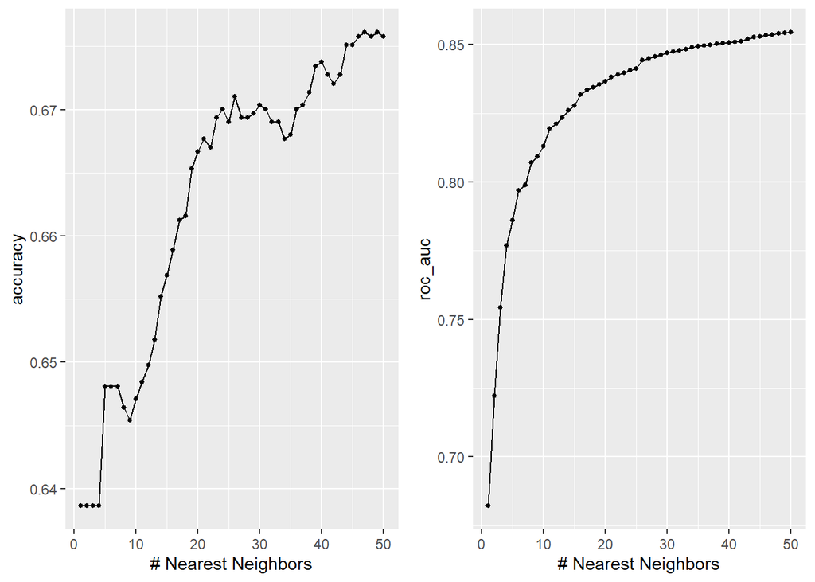

```r
#create the plot for accuracy and roc_auc of knn

plot1 = autoplot(knn_tune_fit, metric = "accuracy")
plot2 = autoplot(knn_tune_fit, metric = "roc_auc")

grid.arrange(plot1, plot2, ncol = 2)
```

From the graph, we can see the best performing knn model has `accuracy` of around 0.675 and `roc_auc` value around 0.85. Also note that as `k` increases, both `accuracy` and the `roc_auc` value are converging to some fixed values.

## Elastic Net

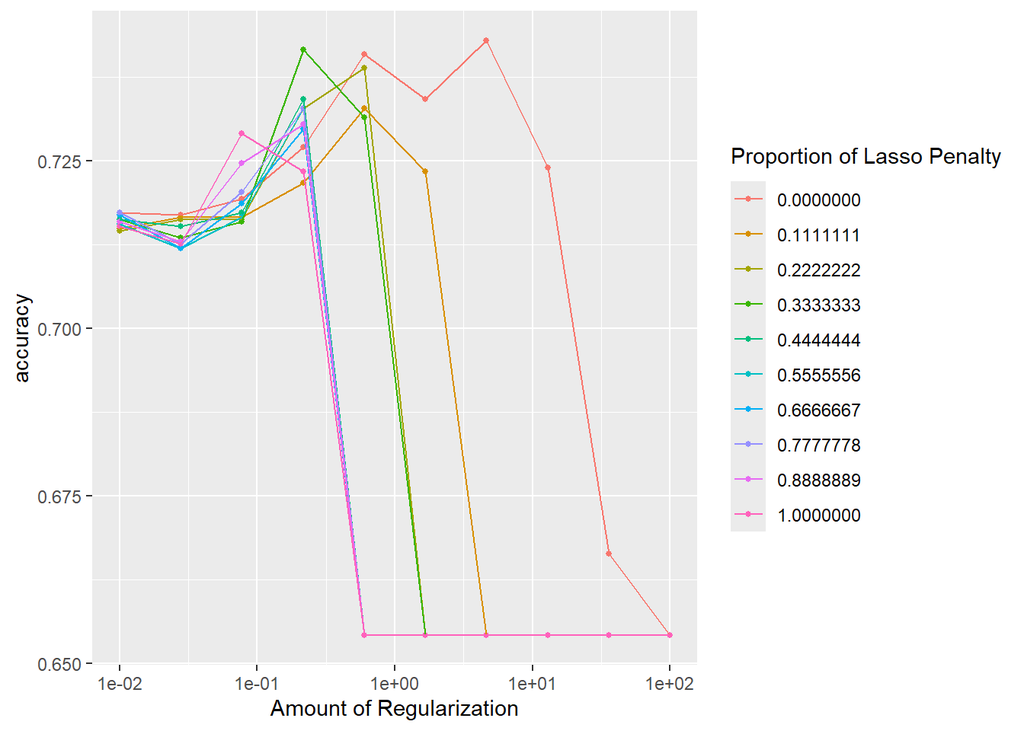

```r
#create the plot for accuracy and roc_auc of elastic net
autoplot(en_tune_fit, metric = "accuracy")
```

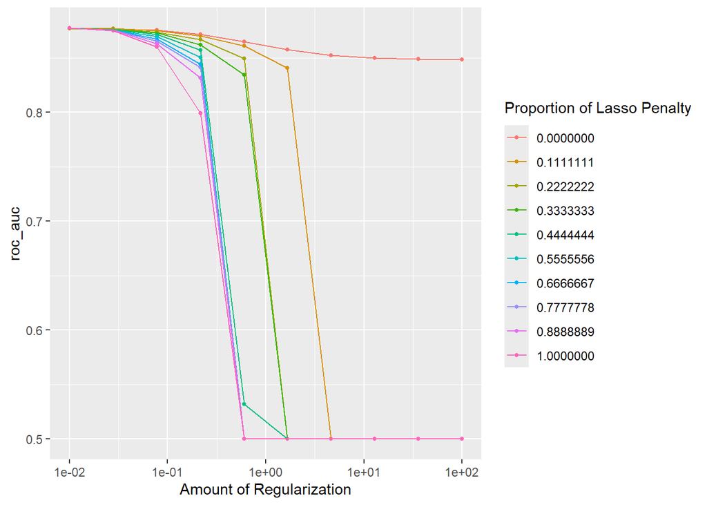

```r
autoplot(en_tune_fit, metric = "roc_auc")
```

From the graph, we can see the best performing elastic net model has `accuracy` around 0.745 and `roc_auc` value around 0.88.

## Random Forest

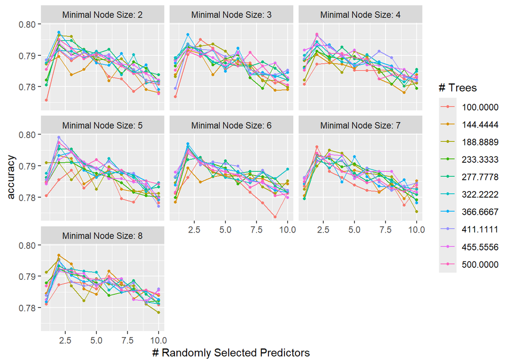

```r
#create the plot for accuracy and roc_auc of random forest
autoplot(rf_tune_fit, metric = "accuracy")
```

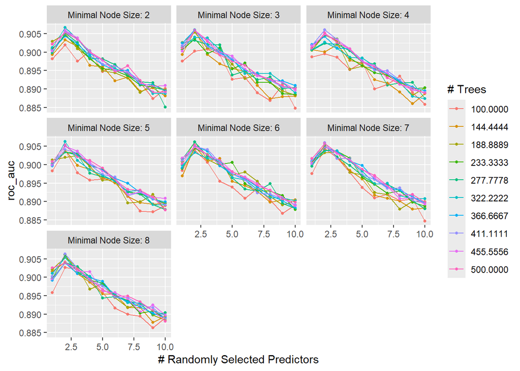

```r
autoplot(rf_tune_fit, metric = "roc_auc")
```

From the graph, we can see the best performing random forest model has `accuracy` around 0.8 and `roc_auc` value around 0.91, which is pretty ideal.

## Selet the best Performing Model

Based on the results we got from fitting and tuning all 4 models, we want to select the best performing mode in terms of `roc_auc`. Notice that the random forest models performed significantly better than the other 3 types of model. Therefore, we will select the best performing model from the different grids of our random forest models.

```r
# select the best model
show_best(rf_tune_fit, n = 3, metric = "roc_auc")
```

```
## # A tibble: 3 × 9
##    mtry trees min_n .metric .estimator  mean     n std_err .config
##   <dbl> <dbl> <dbl> <chr>   <chr>      <dbl> <int>   <dbl> <chr>
## 1     2  322.     2 roc_auc hand_till  0.907    10 0.00982 Preprocessor1_Model1…
## 2     2  411.     8 roc_auc hand_till  0.906    10 0.00983 Preprocessor1_Model1…
## 3     2  322.     5 roc_auc hand_till  0.906    10 0.00997 Preprocessor1_Model1…
```

We can see the best model we got, which has `mtry` = 2, `trees` = 322.22, `min_n` = 2, follows the general trend observed in the auto-plot shown above. The model has a `roc_auc` of 0.9066875, which is consider pretty well performed. Therefore, we can conclude that the model we described is the best performing model.

Additionally, now that we know our best performing model is a random forest model, we can calculate the importance score of all variables and see the ranking of importance of all variables using the `vip` package.

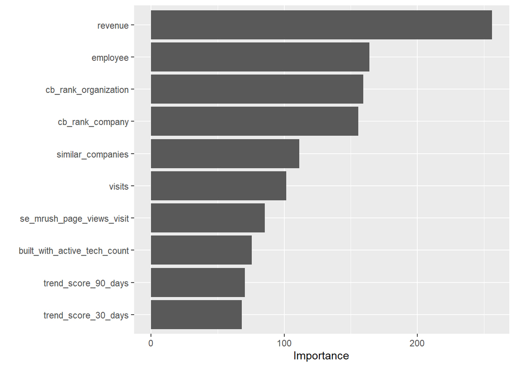

```r
# show the variable importance plot of the best model
cleaned_startup_train = startup_train %>% clean_names()
temp = ranger(success ~ ., data = cleaned_startup_train, importance = "impurity")

vip(temp)
```

As we can see, the most important variable in predicting a company being successful or not is by it’s `revenue`, which makes sense since it is considered one of the most straight forward way to tell if a company is “doing the right thing”, followed by `employee`, which is rather surprise but might be able to be explained by relation between employee and revenue being the key factor of determination. Then, the rankings on CB, which also makes sense since we can assume that the rankings by CB were already determined by numerous factors. On the other hand, variables such as trend scores and active tech counts matter less, but still plays their roll in helping predicting the success of a company.

# Test the Best Model

Now that we have our best model, we will fit it to the testing data and look at the ROC curves, area under the ROC curve, accuracy, and the confusion matrix heat map to assess the performance of the best model.

```r
# fit the best model to our testing set
best_rf = show_best(rf_tune_fit, n = 1, metric = "roc_auc")

final_wflow = finalize_workflow(rf_wflow, best_rf)
final_fit = fit(final_wflow, startup_train)

#save the final fit in an .rda file
save(final_fit, file = "final_fit_2.rda")
```

```r
# load the final fit
load("final_fit_2.rda")
```

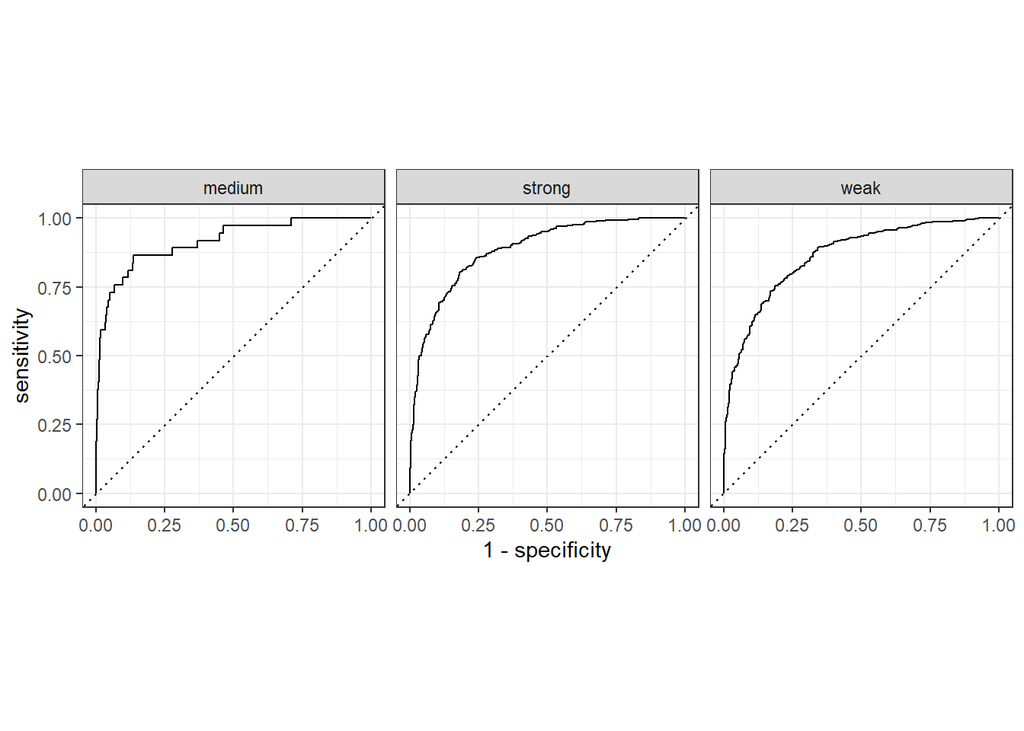

```r
# use final model to predict testing set
final_fit_test = augment(final_fit, new_data = startup_test) %>%
  select(success, starts_with(".pred"))

# graph the roc curves
roc_curve(final_fit_test, truth = success, .pred_strong:.pred_weak) %>%
  autoplot()
```

```r
# find the roc_auc value
roc_auc(final_fit_test, truth = success, .pred_strong:.pred_weak)
```

```
## # A tibble: 1 × 3
##   .metric .estimator .estimate
##   <chr>   <chr>          <dbl>
## 1 roc_auc hand_till      0.896
```

From the ROC curves we can see that our model did a pretty good job predicting all three classes of successes, having well-shaped ROC curves. The overall `roc_auc` of the test fit is 0.896, which is very close to our training `roc_auc`, a pretty surprising and ideal case.

Next, we will look at the accuracy of our test fit.

```r
# find the accuracy of the test fit
final_fit_test %>%
  metrics(truth = success, estimate = .pred_class) %>%
  filter(.metric == "accuracy")
```

```
## # A tibble: 1 × 3
##   .metric  .estimator .estimate
##   <chr>    <chr>          <dbl>
## 1 accuracy multiclass     0.786
```

Observe that the `accuracy` of our model on the testing set is 0.79, while the `accuracy` on the training data is around 0.8, which is approximately the same level. With the `accuracy` being 0.79, we can consider that our best model performed quite well on the test data. We will take a deeper look at the performance by showing the confusion matrix with a heat map to break down the results.

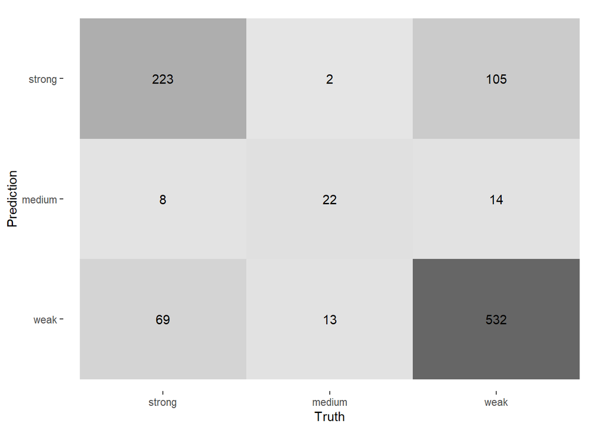

```r
# show the confusion matrix
conf_mat(final_fit_test, truth = success, .pred_class) %>%
  autoplot(type = "heatmap")
```

Here we have the confusion matrix of our predictions on the test data. Let’s break it down by looking at some of the more specific performances. Out of all the actually strong companies, we successfully predicted a good amount (0.743) of them; out of the companies that are actually weak, we also successfully identified a good portion (0.817). This shows that we are particularly good at identifying strong and weak companies, getting most of these two classes correct.

Looking from another perspective, many of the companies (0.676) that we predicted as strong actually turned out to be strong; and most of the companies (0.866) we predicted as weak are actually weak. Note that the accuracy of 0.866 is pretty significant.

Using this model, we can conclude that if we predict a company to be weak, then the company is most likely actually going to turn out weak. Also, if we predict a company to be strong, there is still about a 1/3 chance that the company is not strong, but most of the actually strong companies are within our prediction of strong companies. Therefore, the best use of this model would be to focus on analyzing the companies that we predicted as strong and try to qualitatively identify the companies that are actually strong.

# Prediction on New Companies

## Create and Clean target_data

Now that we have the best performing model, we want to predict the success of the companies founded after 2019, called target_data. First, we clean our data after year 2019 using the same methods as we did for data before 2019. Notice that we don’t create outcome variable `success` since the prediction of the outcome variable is our goal. For better interpretation, we also want to keep the `Organizatioin Name` variable.

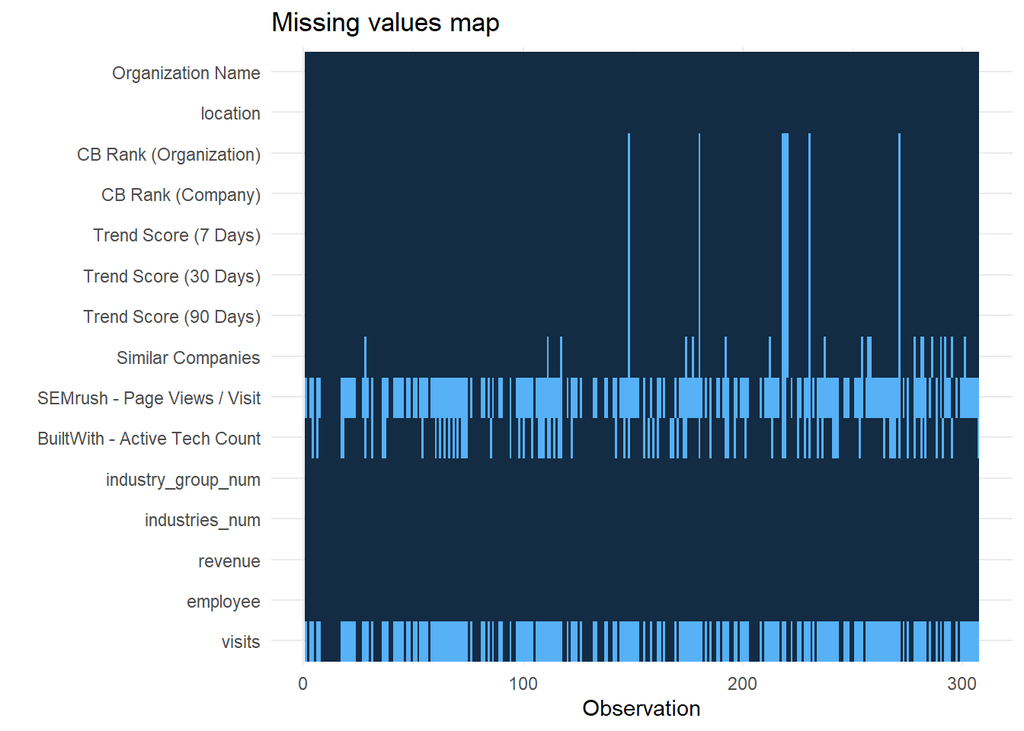

```r
# clean our data after year 2019 and call them target_data

target_data = startup_data_2019_up %>%
  mutate(industry_group_num = str_count(`Industry Groups`, ",") + 1) %>%   # create industry_group_num
  mutate(industries_num = str_count(`Industries`, ",") + 1) %>%    # create industries_num
  mutate(Headquarters = str_split(`Headquarters Location`, pattern = ", ", simplify = TRUE)) %>%
  mutate(Headquarters = Headquarters[,1]) %>%
  mutate(location = sapply(Headquarters, classify_location)) %>%    # create location
  filter(!is.na(location)) %>%
  mutate(revenue = case_when(
    `Estimated Revenue Range` == "Less than $1M" ~ 1,
    `Estimated Revenue Range` == "$1M to $10M" ~ 2,
    `Estimated Revenue Range` == "$10M to $50M" ~ 3,
    `Estimated Revenue Range` == "$50M to $100M" ~ 4,
    `Estimated Revenue Range` == "$100M to $500M" ~ 5,
    `Estimated Revenue Range` == "$500M to $1B" ~ 6,
    `Estimated Revenue Range` == "$1B to $10B" ~ 7,
    `Estimated Revenue Range` == "$10B+" ~ 8,
    TRUE ~ NA
  )) %>%
  mutate(employee = case_when(
    `Number of Employees` == "1-10" ~ 1,
    `Number of Employees` == "11-50" ~ 2,
    `Number of Employees` == "51-100" ~ 3,
    `Number of Employees` == "101-250" ~ 4,
    `Number of Employees` == "251-500" ~ 5,
    `Number of Employees` == "501-1000" ~ 6,
    `Number of Employees` == "1001-5000" ~ 7,
    `Number of Employees` == "5001-10000" ~ 8,
    `Number of Employees` == "$10000+" ~ 8,
    TRUE ~ NA
  )) %>%
  rowwise() %>%
  mutate(
    average_revenue = calculate_average_revenue(`Industry Groups`, revenue_avg),
    revenue = ifelse(is.na(revenue), average_revenue, revenue)
  ) %>%
  select(-average_revenue) %>%   # create revenue
  mutate(
    average_employee = calculate_average_employee(`Industry Groups`, employee_avg),
    employee = ifelse(is.na(employee), average_employee, employee)
  ) %>%
  select(-average_employee) %>%   # create employee
  ungroup() %>%
  mutate(visits = if_else(is.na(`SEMrush - Average Visits (6 months)`),
                          `SEMrush - Monthly Visits`,
                          `SEMrush - Average Visits (6 months)`)) %>%   # create visit
  select(`Organization Name`, location, `CB Rank (Organization)`, `CB Rank (Company)`, `Trend Score (7 Days)`, `Trend Score (30 Days)`, `Trend Score (90 Days)`, `Similar Companies`, `SEMrush - Page Views / Visit`, `BuiltWith - Active Tech Count`, `industry_group_num`, `industries_num`, `revenue`, `employee`, `visits`)    # select useful parameters, note that there is no 'success'

target_data %>% missing_plot()
```

Since the pattern of the missing plot is similar to what we saw earlier with data from 2018 and before, we handle the missing value the same way as previous methods.

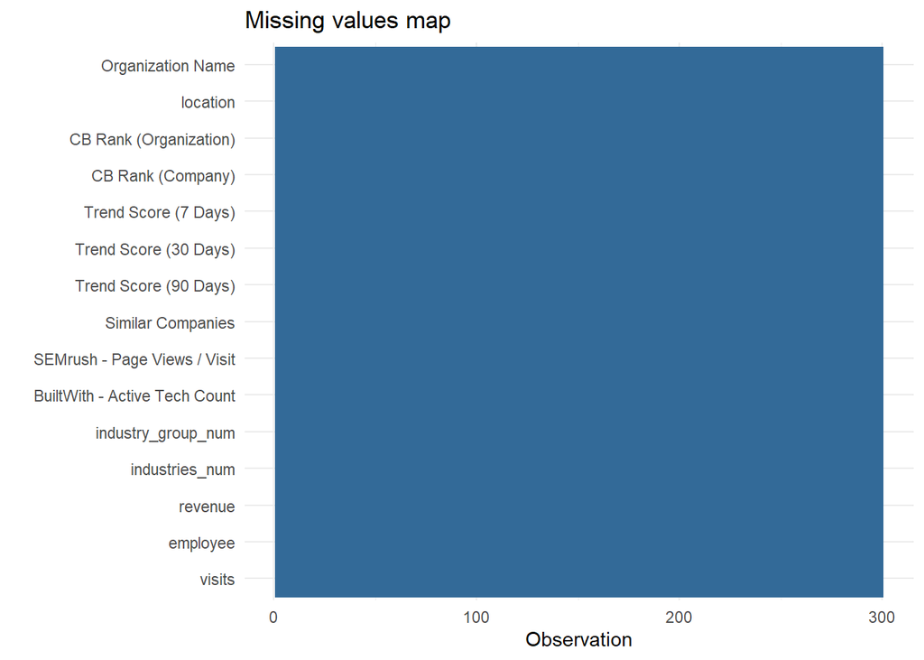

```r
# discard the observations with too many missing values and impute the rest with knn with k = 5

target_data = target_data %>%
  filter(is.na(`CB Rank (Organization)`) == FALSE) %>%
  kNN(k=5) %>%
  select(`Organization Name`, location, `CB Rank (Organization)`, `CB Rank (Company)`, `Trend Score (7 Days)`, `Trend Score (30 Days)`, `Trend Score (90 Days)`, `Similar Companies`, `SEMrush - Page Views / Visit`, `BuiltWith - Active Tech Count`, `industry_group_num`, `industries_num`, `revenue`, `employee`, `visits`)

# create the missing plot for target_data after filling the missing values
target_data %>% missing_plot()
```

Now that we’ve cleaned our data after year 2019, we can start predicting the outcome, `success`, with our best performing model and look at the results.

## Prediction Results

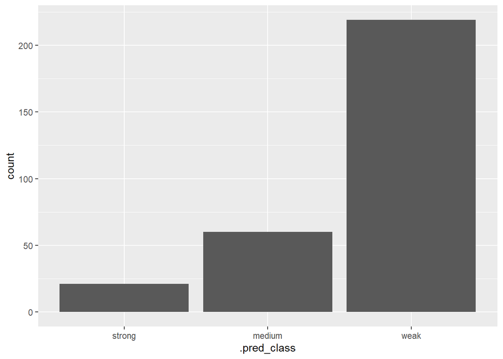

```r
# predict success of new companies and plot the distributions of predictions
prediction = predict(final_fit, target_data)

prediction_results = target_data %>%
  bind_cols(prediction) %>%
  select(`Organization Name`, .pred_class)

prediction_results %>% ggplot(aes(x = .pred_class)) + geom_bar()
```

Looking at the distribution of predictions for newer companies, we can observe that this distribution of success is not very similar to the distribution of `success` we saw in our training data. The best explanation for this is that we know variables like `revenue` and `employee` count are the most important factors in predicting the success of a company. It is likely that the newer companies are smaller in scale and might not be as prominent as the already established firms. In other words, these companies are still in the earlier stages of their cycles, so fewer companies will meet the criteria for being identified as “successful.”

With that being said, the scarcity of “strong” predicted companies raises their value, so investors would definitely want to take a closer look at companies predicted to be “strong.” Here, we list these companies for future reference and investment considerations:

```r
#list the companies which the model predicted to be strong

prediction_results %>% filter(.pred_class == "strong")
```

```
##                            Organization Name .pred_class
## 1                                        GDT      strong
## 2                           Numbers Protocol      strong
## 3                                    Syncell      strong
## 4                     Sunhawk Vision Biotech      strong
## 5                                JustKitchen      strong
## 6           Yield Guild Games Southeast Asia      strong
## 7                       Ancora Semiconductor      strong
## 8  aiFree Interactive Technology Corporation      strong
## 9                                WOO Network      strong
## 10                          Teahouse Finance      strong
## 11                           portto / Blocto      strong
## 12                                 Next Bank      strong
## 13                          Red Door Digital      strong
## 14                                  Jmem Tek      strong
## 15                            TXOne Networks      strong
## 16                                     Cooby      strong
## 17                           URSROBOT AI INC      strong
## 18               HippoScreen Neurotech Corp.      strong
## 19                          AUO Display Plus      strong
## 20                                 Heptabase      strong
## 21                 LSC Ecosystem Corporation      strong
```

```r
temp = prediction_results %>%
  filter(.pred_class == "strong" |.pred_class == "medium") %>%
  nrow()

paste("Number of companies predicted to be strong or medium:", temp)
```

```
## [1] "Number of companies predicted to be strong or medium: 81"
```

There are 21 of these companies that the model sees high potential in, if an investor wants more options, we can expand to the “medium” classified companies, which totaled the list to have 81 observations.

# Conclusion and Future Improvements

In this project, the first problem we faced was the question: How do we define success with the given dataset? Since every entrepreneur and investor has a different personal definition of “success,” we eventually chose to be more straightforward and objective, defining a company as successful if it has either gone public (IPO), been acquired (M&A), or received a top-percent amount of funding. People using our model to predict the success of startups should keep in mind this definition and use it as the “success” described by the model, not interpreting the term “success” in any other way.

Furthermore, we faced a significant obstacle presented by a dataset with a large proportion of missing values. Data cleaning required various methods to address the missing values, from feature engineering to imputing missing values by taking the average over certain classifications. I believe the data cleaning process went well because, alternatively, we would have had to discard many important variables if we had not found a reasonable way to impute the missing values or simply filled them with KNN.

For model selection, we tried four different models: logistic regression, KNN, elastic net, and random forest. Out of these four models, random forest performed the best, and we successfully achieved an area under the ROC curve of over 90% with our training data and nearly 90% with our testing data. The overall accuracy of the model is around 80%, which is also quite satisfying.

Though the outcome of this project is rather ideal, there are still some flaws and cautions in using such a model, particularly regarding the quality of prediction in each class. For example, the model has a good percentage of successfully predicting weak companies, but 1/3 of its “strong” predictions are false. However, most of the actual strong companies are included in the remaining 2/3 of the “strong” predictions. The suggested way to most efficiently use this model is to use the “strong” predictions as a filter to help single out the companies with the best potential and that are projected to be the most successful out of a pool of startups. We can confidently disregard the “weak” predictions, and if we want to expand our choices, we can also look at the “medium” classified companies, as they are next in line for having good chances of becoming successful. After getting the predictions, investors and entrepreneurs are encouraged to apply further qualitative analysis, along with their experience, to select the companies they truly see potential in. In other words, this model should act as a guideline rather than a precise fortune teller.

The most direct way to improve the performance of this model is to collect a more thorough dataset. In the original dataset, numerous variables, if not mostly missing values, should improve the model’s performance by a wide margin. Furthermore, we chose to discard the year founded information since our prediction target is newer companies, and their year founded information would be out of range in the training process of our model. Including this information could seriously harm the quality of predictions. However, if we still want to take the year founded into consideration, which is arguably a very important indicator, we might need to apply a model that adapts time series analysis. If there were a model that combined tree-based models with time series analysis, I think we could significantly improve our model. Perhaps the use of neural networks would be helpful, too. These improvements are yet to be discovered, and we will enhance the model as I master these other methods.

Besides dataset comprehension and model proficiency, there are some other aspects we can tune to improve the model using the methods described. These “aspects” include the proportion of the train/test split, the consideration of different industries (since there are so many, I concatenated them as one column counting the number of industries a company crosses, but it is conceivable that the type of industries a company operates in would highly affect its chance of success), and the inclusion of companies missing the year founded value (I discarded these companies since we would not know if we should train with the data or put them in the target dataset in case they are “new companies,” but we might be able to obtain much of this missing information through data mining).

Overall, I am very satisfied with the result and performance of this model. I am very grateful that ITRI provided me with the opportunity and resources to create and complete this project independently with the professional guidance of my mentor. I’m looking forward to more future opportunities related to machine learning, and I hope that in the future I can continue to work with more complex real-life datasets to solve business problems quantitatively and improve the decision-making process to become more prudent and more robust.